# Factors with `forcats`

Material adapted from the textbook, *“R for Data Science”* (R4DS) by Hadley Wickham and Garret Grolemund. The official website of the textbook is http://r4ds.had.co.nz/

Load the required packages

```r
library(tidyverse)
```

We will use the [package `forcats`](https://forcats.tidyverse.org/) which provides tools for dealing with **cat**egorical variables (and it’s an anagram of factors!).

```r
library(forcats)
```

## Factors and Levels

Factors are how categorical information gets stored in R. Remember that *categorical variables* are a type of variable that take on a *name or label*. For example: countries, colors, car makes, a [likert scale](https://en.wikipedia.org/wiki/Likert_scale).

Factors often look like *strings*, but behave more like numbers. This is because R is storing each level within a factor as an integer. R assigns integers to each level using alphabetical order.

[figure not shown]

### General Social Survey

A sample of categorical variables from the General Social survey is included in the `gss_cat` data frame included in `forcats`

```r
gss_cat
```

| year | marital | age | race | rincome | partyid | relig | denom | tvhours |
| --- | --- | --- | --- | --- | --- | --- | --- | --- |
| 2000 | Never married | 26 | White | $8000 to 9999 | Ind,near rep | Protestant | Southern baptist | 12 |
| 2000 | Divorced | 48 | White | $8000 to 9999 | Not str republican | Protestant | Baptist-dk which | NA |
| 2000 | Widowed | 67 | White | Not applicable | Independent | Protestant | No denomination | 2 |
| 2000 | Never married | 39 | White | Not applicable | Ind,near rep | Orthodox-christian | Not applicable | 4 |
| 2000 | Divorced | 25 | White | Not applicable | Not str democrat | None | Not applicable | 1 |
| 2000 | Married | 25 | White | $20000 - 24999 | Strong democrat | Protestant | Southern baptist | NA |
| 2000 | Never married | 36 | White | $25000 or more | Not str republican | Christian | Not applicable | 3 |
| 2000 | Divorced | 44 | White | $7000 to 7999 | Ind,near dem | Protestant | Lutheran-mo synod | NA |
| 2000 | Married | 44 | White | $25000 or more | Not str democrat | Protestant | Other | 0 |
| 2000 | Married | 47 | White | $25000 or more | Strong republican | Protestant | Southern baptist | 3 |

[output cut: 990 more lines]

Notice:

- `marital` is a **factor** within our dataset
- “Never married”, “Divorced”, and “Married” are all **levels** of the factor `marital`

If we use the `str()` function we can easily see the different levels of all the factors in our dataset

```r
str(gss_cat)
```

```
tibble [21,483 x 9] (S3: tbl_df/tbl/data.frame)
 $ year   : int [1:21483] 2000 2000 2000 2000 2000 2000 2000 2000 2000 2000 ...
 $ marital: Factor w/ 6 levels "No answer","Never married",..: 2 4 5 2 4 6 2 4 6 6 ...
 $ age    : int [1:21483] 26 48 67 39 25 25 36 44 44 47 ...
 $ race   : Factor w/ 4 levels "Other","Black",..: 3 3 3 3 3 3 3 3 3 3 ...
 $ rincome: Factor w/ 16 levels "No answer","Don't know",..: 8 8 16 16 16 5 4 9 4 4 ...
 $ partyid: Factor w/ 10 levels "No answer","Don't know",..: 6 5 7 6 9 10 5 8 9 4 ...
 $ relig  : Factor w/ 16 levels "No answer","Don't know",..: 15 15 15 6 12 15 5 15 15 15 ...
 $ denom  : Factor w/ 30 levels "No answer","Don't know",..: 25 23 3 30 30 25 30 15 4 25 ...
 $ tvhours: int [1:21483] 12 NA 2 4 1 NA 3 NA 0 3 ...
```

Notice that there are 6 factors in our dataset:

| factor | description | levels |
| --- | --- | --- |
| `marital` | marital status | 6 |
| `race` | race | 4 |
| `rincome` | reported income | 16 |
| `partyid` | party affiliation | 10 |
| `relig` | religion | 16 |
| `denom` | denomination | 30 |

We can also use the `count()` function:

```r
gss_cat %>%
  count(race)
```

| race | n |
| --- | --- |
| Other | 1959 |
| Black | 3129 |
| White | 16395 |

We can see this also by creating a bar plot:

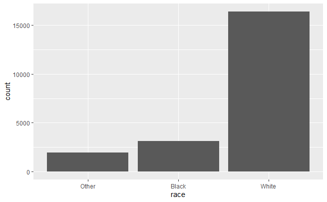

```r
ggplot(gss_cat, aes(race)) +
  geom_bar()
```

## Modifying factor order

It is often useful to change the *order* of the factor levels in a visualization. For example, imagine you want to explore the average number of hours spent watching TV per day across religions:

First create an object containing the summaries

```r
relig_summary <- gss_cat %>%
                  group_by(relig) %>%
                  summarise(
                            age = mean(age, na.rm = TRUE),
                            tvhours = mean(tvhours, na.rm = TRUE),
                            n = n()
                  )
```

and then use `ggplot` to create a visualization:

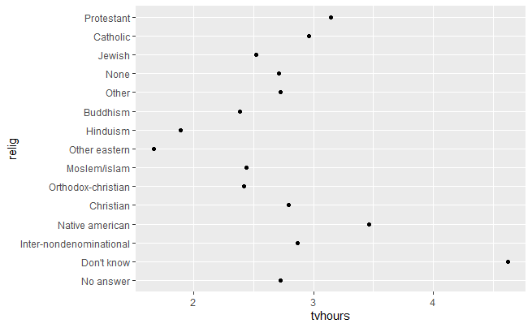

```r
ggplot(relig_summary, aes(tvhours, relig)) +
  geom_point()
```

In this plot because there is no overall pattern. We can improve it by *reordering the levels* of `relig` using `fct_reorder()`.

`fct_reorder()` takes three arguments:

- `f`, the factor whose levels you want to modify.
- `x`, a numeric vector that you want to use to reorder the levels.
- Optionally, `fun`, a function that’s used if there are multiple values of `x` for each value of `f`. The default value is `median`.

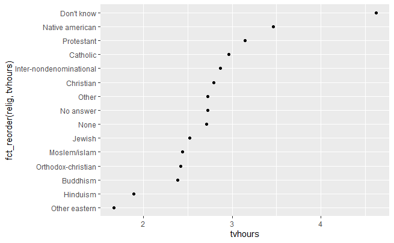

```r
ggplot(relig_summary, aes(tvhours, fct_reorder(relig, tvhours))) +
  geom_point()
```

What if we create a similar plot looking at how *average age* varies across reported income level?

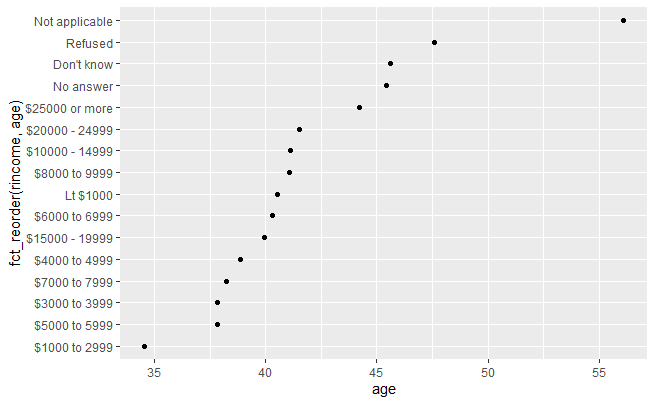

```r
rincome_summary <- gss_cat %>%
  group_by(rincome) %>%
  summarise(
    age = mean(age, na.rm = TRUE),
    tvhours = mean(tvhours, na.rm = TRUE),
    n = n()
  )

ggplot(rincome_summary, aes(age, fct_reorder(rincome, age))) +
  geom_point()
```

```r
NA
```

Here, arbitrarily reordering the levels is not a good idea! That’s because `rincome` already has a *principled order* that we should not mess with. *Reserve `fct_reorder()` for factors whose levels are arbitrarily ordered.*

However, it does make sense to pull “Not applicable” to the front with the other special levels. You can use `fct_relevel()`. It takes a factor, `f`, and then any number of levels that you want to move to the front of the line.

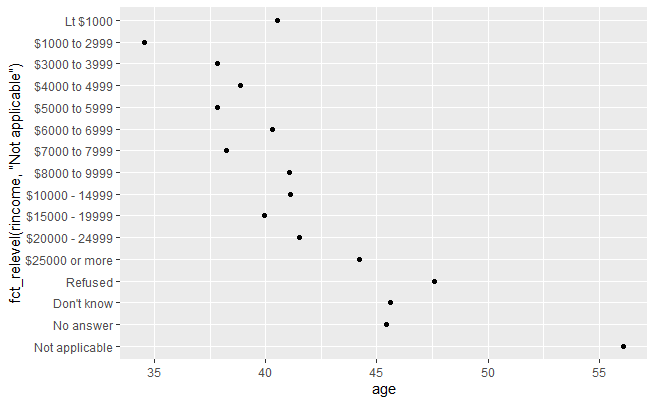

```r
ggplot(rincome_summary, aes(age, fct_relevel(rincome, "Not applicable"))) +
  geom_point()
```

## Modifying factor levels

More powerful than changing the orders of the levels is changing their values. This allows you to clarify labels for publication, and collapse levels for high-level displays. The most general and powerful tool is `fct_recode()`. It allows you to recode, or change, the value of each level.

For example, take the `gss_cat$partyid`:

```r
gss_cat %>%
  count(partyid)
```

| partyid | n |
| --- | --- |
| No answer | 154 |
| Don't know | 1 |
| Other party | 393 |
| Strong republican | 2314 |
| Not str republican | 3032 |
| Ind,near rep | 1791 |
| Independent | 4119 |
| Ind,near dem | 2499 |
| Not str democrat | 3690 |
| Strong democrat | 3490 |

```r
NA
```

The levels are terse and inconsistent.

```r
gss_cat %>%
  mutate(partyid = fct_recode(partyid,
    "Republican, strong"    = "Strong republican",
    "Republican, weak"      = "Not str republican",
    "Independent, near rep" = "Ind,near rep",
    "Independent, near dem" = "Ind,near dem",
    "Democrat, weak"        = "Not str democrat",
    "Democrat, strong"      = "Strong democrat"
  )) %>%
  count(partyid)
```

| partyid | n |
| --- | --- |
| No answer | 154 |
| Don't know | 1 |
| Other party | 393 |
| Republican, strong | 2314 |
| Republican, weak | 3032 |
| Independent, near rep | 1791 |
| Independent | 4119 |
| Independent, near dem | 2499 |
| Democrat, weak | 3690 |
| Democrat, strong | 3490 |

`fct_recode()` will leave levels that are not explicitly mentioned as is, and will warn you if you accidentally refer to a level that does not exist.

To combine groups, you can assign multiple old levels to the same new level:

```r
gss_cat %>%
  mutate(partyid = fct_recode(partyid,
    "Republican, strong"    = "Strong republican",
    "Republican, weak"      = "Not str republican",
    "Independent, near rep" = "Ind,near rep",
    "Independent, near dem" = "Ind,near dem",
    "Democrat, weak"        = "Not str democrat",
    "Democrat, strong"      = "Strong democrat",
    "Other"                 = "No answer",
    "Other"                 = "Don't know",
    "Other"                 = "Other party"
  )) %>%
  count(partyid)
```

| partyid | n |
| --- | --- |
| Other | 548 |
| Republican, strong | 2314 |
| Republican, weak | 3032 |
| Independent, near rep | 1791 |
| Independent | 4119 |
| Independent, near dem | 2499 |
| Democrat, weak | 3690 |
| Democrat, strong | 3490 |

## Other Examples

Consider the `airquality` dataset that contains daily air quality measurements in New York, May to September 1973.

```r
glimpse(airquality)
```

```
Rows: 153
Columns: 6
$ Ozone   <int> 41, 36, 12, 18, NA, 28, 23, 19, 8, NA, 7, 16, 11, 14, 18, 14~
$ Solar.R <int> 190, 118, 149, 313, NA, NA, 299, 99, 19, 194, NA, 256, 290, ~
$ Wind    <dbl> 7.4, 8.0, 12.6, 11.5, 14.3, 14.9, 8.6, 13.8, 20.1, 8.6, 6.9,~
$ Temp    <int> 67, 72, 74, 62, 56, 66, 65, 59, 61, 69, 74, 69, 66, 68, 58, ~
$ Month   <int> 5, 5, 5, 5, 5, 5, 5, 5, 5, 5, 5, 5, 5, 5, 5, 5, 5, 5, 5, 5, ~
$ Day     <int> 1, 2, 3, 4, 5, 6, 7, 8, 9, 10, 11, 12, 13, 14, 15, 16, 17, 1~
```

Let us convert the variable `Month` to a factor

```r
airquality$Month <- factor(airquality$Month)
airquality$Month
```

```
  [1] 5 5 5 5 5 5 5 5 5 5 5 5 5 5 5 5 5 5 5 5 5 5 5 5 5 5 5 5 5 5 5 6 6 6 6 6
 [37] 6 6 6 6 6 6 6 6 6 6 6 6 6 6 6 6 6 6 6 6 6 6 6 6 6 7 7 7 7 7 7 7 7 7 7 7
 [73] 7 7 7 7 7 7 7 7 7 7 7 7 7 7 7 7 7 7 7 7 8 8 8 8 8 8 8 8 8 8 8 8 8 8 8 8
[109] 8 8 8 8 8 8 8 8 8 8 8 8 8 8 8 9 9 9 9 9 9 9 9 9 9 9 9 9 9 9 9 9 9 9 9 9
[145] 9 9 9 9 9 9 9 9 9
Levels: 5 6 7 8 9
```

and we can also rename the months using the `fct_recode()` function:

```r
airquality$Month <- fct_recode(airquality$Month, May = '5', June = '6', July = '7', Aug = '8', Sept = '9')
glimpse(airquality$Month)
```

```
 Factor w/ 5 levels "May","June","July",..: 1 1 1 1 1 1 1 1 1 1 ...
```

Sometimes it is useful to *reorder* the factor in a way that is useful for visualization. For this, we can use the `fct_reorder()` function.